# Course Project 1

Aditya Iyengar

09/04/2020

This is the documentation for Course Project 1 for the online course **Reproducible Research** offered by *Johns Hopkins University* on Coursera.  
You can find the project details in the Readme file.

### Step 1: Loading and Preprocessing the Data

Let’s load the data from the link and unzip it.

```r
download.file("https://d396qusza40orc.cloudfront.net/repdata%2Fdata%2Factivity.zip", "activity.zip", method = "curl")
dataset <- read.csv(unzip("activity.zip"))
```

Here’s a basic overview of the dataset.

```r
str(dataset)
```

```
## 'data.frame':    17568 obs. of  3 variables:
##  $ steps   : int  NA NA NA NA NA NA NA NA NA NA ...
##  $ date    : Factor w/ 61 levels "2012-10-01","2012-10-02",..: 1 1 1 1 1 1 1 1 1 1 ...
##  $ interval: int  0 5 10 15 20 25 30 35 40 45 ...
```

Let’s also process the dates by converting them using the *lubridate* package.

```r
library(lubridate)
dataset$date <- ymd(dataset$date)
```

### Step 2: Analysis of the number of steps taken

First, we calculate the total number of steps per day.

```r
dailysteps <- tapply(dataset$steps, dataset$date, sum, na.rm = TRUE)
```

We then calculate the mean and median steps taken per day.

```r
print(paste("Mean steps per day:", (round(mean(dailysteps, na.rm = TRUE), digits = 2))))
```

```
## [1] "Mean steps per day: 9354.23"
```

```r
print(paste("Median steps per day:", (round(median(dailysteps, na.rm = TRUE), digits = 2))))
```

```
## [1] "Median steps per day: 10395"
```

Here is a histogram plot of the number of steps per day.

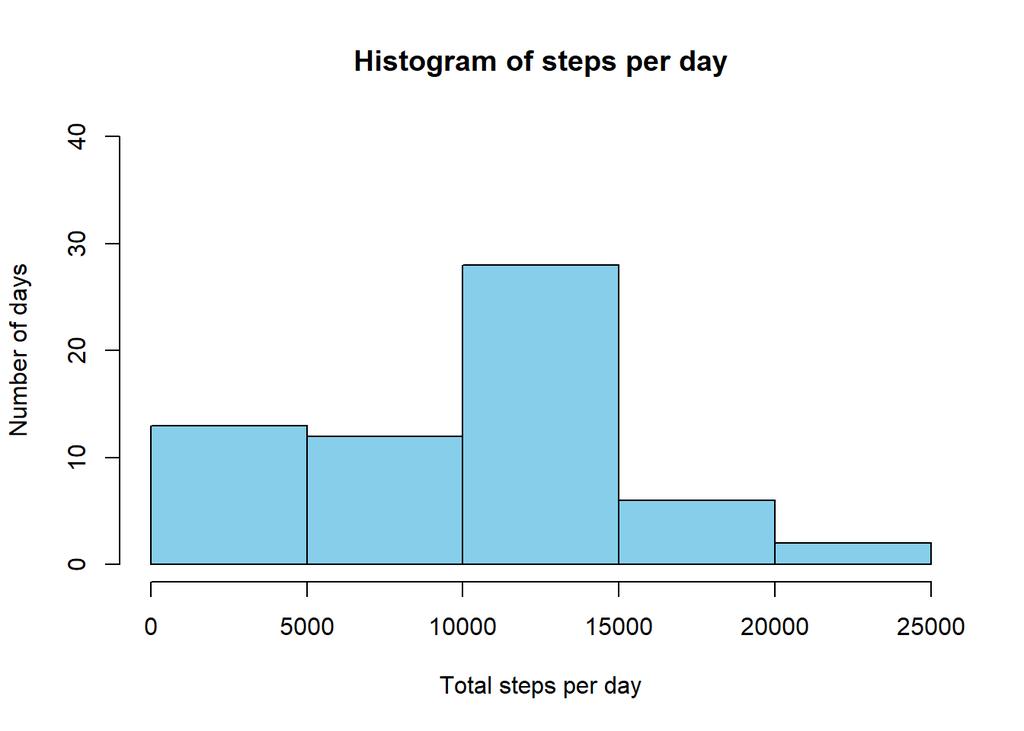

```r
hist(dailysteps, main = "Histogram of steps per day", xlab = "Total steps per day", ylab = "Number of days", col = "skyblue", ylim = c(0, 40))
```

### Step 3: Average Daily Activity Pattern

The time interval with the maximum steps per day, on an average is given by:

```r
stepstime <- tapply(dataset$steps, dataset$interval, mean, na.rm=TRUE)
print(paste(names(which(stepstime == max(stepstime))), "with", max(stepstime), "steps on an average"))
```

```
## [1] "835 with 206.169811320755 steps on an average"
```

Here is a time series plot of the average daily activity trend.

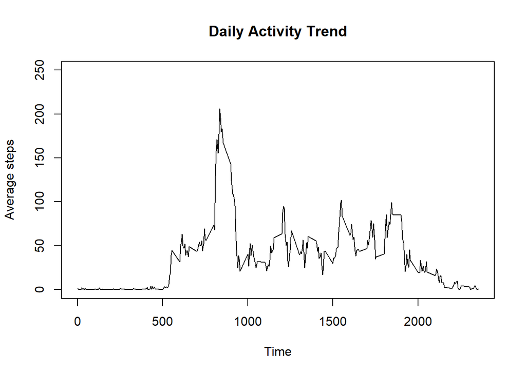

```r
plot(names(stepstime), stepstime, type='l', main = "Daily Activity Trend", xlab = "Time", ylab = "Average steps", ylim = c(0, 250))
```

### Step 4: Imputing Missing Values

```r
print(paste("Number of missing values:", sum(is.na(dataset))))
```

```
## [1] "Number of missing values: 2304"
```

To impute the missing values, we will use the mean steps during that particular time interval over the entire dataset.

```r
dataset1 <- dataset
dataset1 <- cbind(dataset, stepstime)
for(i in 1:length(dataset1$steps)){
  if(is.na(dataset1$steps[i])==TRUE){
    dataset1$steps[i] <- dataset1$stepstime[i]
  }
}
```

Let us attempt to analyze this new dataset. First, we calculate the total number of steps per day.

```r
dailysteps1 <- tapply(dataset1$steps, dataset1$date, sum, na.rm = TRUE)
```

We then calculate the mean and median steps taken per day.

```r
print(paste("Mean steps per day:", (round(mean(dailysteps1, na.rm = TRUE), digits = 2))))
```

```
## [1] "Mean steps per day: 10766.19"
```

```r
print(paste("Median steps per day:", (round(median(dailysteps1, na.rm = TRUE), digits = 2))))
```

```
## [1] "Median steps per day: 10766.19"
```

We observe an increase in the mean and median steps per day. This occurs because the NA values are replaced by average imputed values.  
Here is a histogram plot of the number of steps per day.

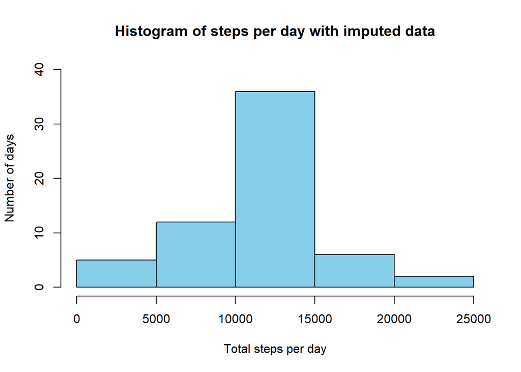

```r
hist(dailysteps1, main = "Histogram of steps per day with imputed data", xlab = "Total steps per day", ylab = "Number of days", col = "skyblue", ylim = c(0, 40))
```

### Step 5: Weekends vs Weekdays

Let us compare the daily activity trend for weekends and weekdays.

```r
library(chron)
```

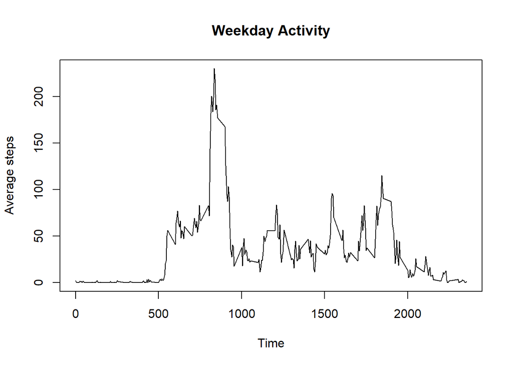

```r
dataset2 <- dataset1
isweekend <- is.weekend(dataset2$date)
dataset2 <- cbind(dataset2, isweekend)
dataset3 <- dataset2
for(i in 17568:1){
  if(dataset2$isweekend[i]==TRUE){
    dataset2 <- dataset2[-i, ]
  }
}
for(i in 17568:1){
  if(dataset3$isweekend[i]==FALSE){
    dataset3 <- dataset3[-i, ]
  }
}
stepstime2 <- tapply(dataset2$steps, dataset2$interval, mean, na.rm=TRUE)
stepstime3 <- tapply(dataset3$steps, dataset3$interval, mean, na.rm=TRUE)
plot(names(stepstime2), stepstime2, main = "Weekday Activity", type = "l", xlab = "Time", ylab = "Average steps")
```

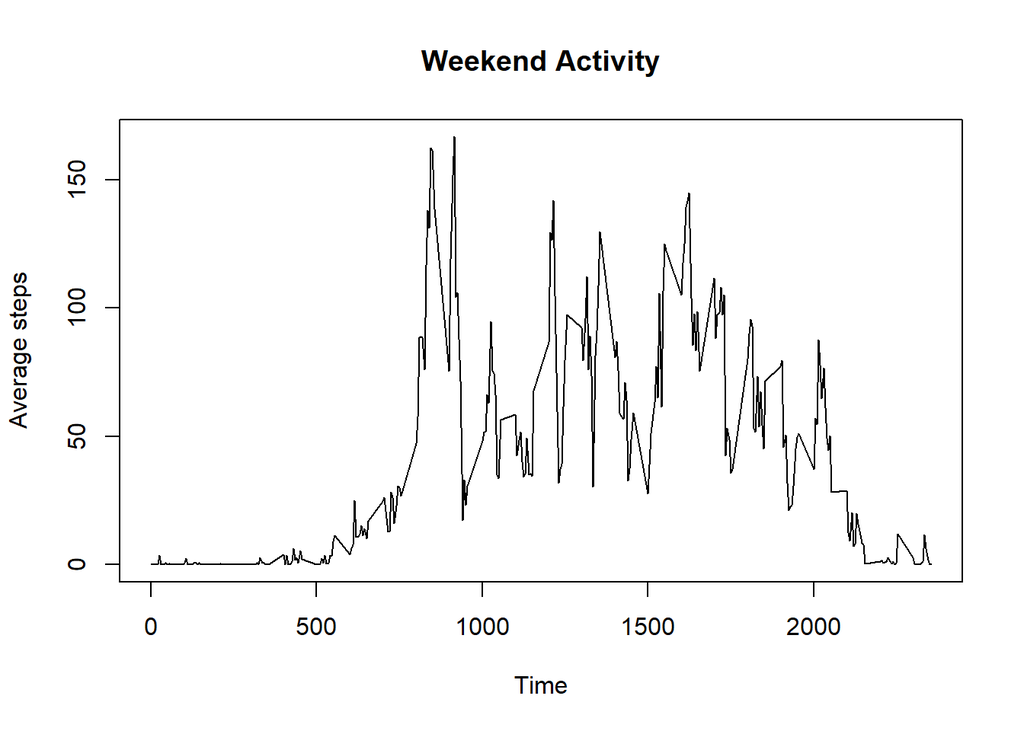

```r
plot(names(stepstime3), stepstime3, main = "Weekend Activity", type = "l", xlab = "Time", ylab = "Average steps")
```